# Optimal Treatment Analysis

## Outcome Variable

**Outcome Variable:** whz

## Predictor Variables

**Intervention Variable:** earlybf

**Adjustment Set:**

- arm
- sex
- W_mage
- meducyrs
- feducyrs
- hhwealth_quart
- hfoodsec
- W_mhtcm
- W_mwtkg
- W_mbmi
- vagbrth
- W_gagebrth
- W_birthwt
- W_birthlen
- W_nrooms
- W_nchldlt5
- brthmon
- W_parity
- impfloor
- impsan
- safeh20
- delta_W_mage
- delta_meducyrs
- delta_feducyrs
- delta_hhwealth_quart
- delta_hfoodsec
- delta_W_mhtcm
- delta_W_mwtkg
- delta_W_mbmi
- delta_vagbrth
- delta_W_gagebrth
- delta_W_birthwt
- delta_W_birthlen
- delta_W_nrooms
- delta_W_nchldlt5
- delta_brthmon
- delta_W_parity
- delta_impfloor
- delta_impsan
- delta_safeh20

## Stratifying Variables

The analysis was stratified on these variable(s):

- agecat
- studyid
- country

## Data Summary

| agecat | studyid | country | earlybf | n_cell | n |
| --- | --- | --- | --- | --- | --- |
| Birth | ki0047075b-MAL-ED | BANGLADESH | 1 | 140 | 214 |
| Birth | ki0047075b-MAL-ED | BANGLADESH | 0 | 74 | 214 |
| Birth | ki0047075b-MAL-ED | BRAZIL | 1 | 26 | 62 |
| Birth | ki0047075b-MAL-ED | BRAZIL | 0 | 36 | 62 |
| Birth | ki0047075b-MAL-ED | INDIA | 1 | 31 | 44 |
| Birth | ki0047075b-MAL-ED | INDIA | 0 | 13 | 44 |
| Birth | ki0047075b-MAL-ED | NEPAL | 1 | 14 | 26 |
| Birth | ki0047075b-MAL-ED | NEPAL | 0 | 12 | 26 |
| Birth | ki0047075b-MAL-ED | PERU | 1 | 172 | 228 |
| Birth | ki0047075b-MAL-ED | PERU | 0 | 56 | 228 |
| Birth | ki0047075b-MAL-ED | SOUTH AFRICA | 1 | 69 | 110 |
| Birth | ki0047075b-MAL-ED | SOUTH AFRICA | 0 | 41 | 110 |
| Birth | ki0047075b-MAL-ED | TANZANIA, UNITED REPUBLIC OF | 1 | 103 | 115 |
| Birth | ki0047075b-MAL-ED | TANZANIA, UNITED REPUBLIC OF | 0 | 12 | 115 |
| Birth | ki1000109-EE | PAKISTAN | 1 | 36 | 170 |
| Birth | ki1000109-EE | PAKISTAN | 0 | 134 | 170 |
| Birth | ki1000304b-SAS-CompFeed | INDIA | 1 | 79 | 1072 |
| Birth | ki1000304b-SAS-CompFeed | INDIA | 0 | 993 | 1072 |
| Birth | ki1017093c-NIH-Crypto | BANGLADESH | 1 | 613 | 707 |
| Birth | ki1017093c-NIH-Crypto | BANGLADESH | 0 | 94 | 707 |
| Birth | ki1113344-GMS-Nepal | NEPAL | 1 | 171 | 586 |
| Birth | ki1113344-GMS-Nepal | NEPAL | 0 | 415 | 586 |
| Birth | ki1126311-ZVITAMBO | ZIMBABWE | 1 | 6142 | 11514 |
| Birth | ki1126311-ZVITAMBO | ZIMBABWE | 0 | 5372 | 11514 |
| Birth | kiGH5241-JiVitA-3 | BANGLADESH | 1 | 105 | 17943 |
| Birth | kiGH5241-JiVitA-3 | BANGLADESH | 0 | 17838 | 17943 |
| Birth | kiGH5241-JiVitA-4 | BANGLADESH | 1 | 1624 | 2396 |
| Birth | kiGH5241-JiVitA-4 | BANGLADESH | 0 | 772 | 2396 |
| 6 months | ki0047075b-MAL-ED | BANGLADESH | 1 | 147 | 240 |
| 6 months | ki0047075b-MAL-ED | BANGLADESH | 0 | 93 | 240 |

[output cut: 52 more lines]

The following strata were considered:

- agecat: 24 months, studyid: ki0047075b-MAL-ED, country: BANGLADESH
- agecat: 24 months, studyid: ki0047075b-MAL-ED, country: BRAZIL
- agecat: 24 months, studyid: ki0047075b-MAL-ED, country: INDIA
- agecat: 24 months, studyid: ki0047075b-MAL-ED, country: NEPAL
- agecat: 24 months, studyid: ki0047075b-MAL-ED, country: PERU
- agecat: 24 months, studyid: ki0047075b-MAL-ED, country: SOUTH AFRICA
- agecat: 24 months, studyid: ki0047075b-MAL-ED, country: TANZANIA, UNITED REPUBLIC OF
- agecat: 24 months, studyid: ki1000109-EE, country: PAKISTAN
- agecat: 24 months, studyid: ki1017093c-NIH-Crypto, country: BANGLADESH
- agecat: 24 months, studyid: ki1113344-GMS-Nepal, country: NEPAL
- agecat: 24 months, studyid: ki1126311-ZVITAMBO, country: ZIMBABWE
- agecat: 24 months, studyid: kiGH5241-JiVitA-3, country: BANGLADESH
- agecat: 24 months, studyid: kiGH5241-JiVitA-4, country: BANGLADESH
- agecat: 6 months, studyid: ki0047075b-MAL-ED, country: BANGLADESH
- agecat: 6 months, studyid: ki0047075b-MAL-ED, country: BRAZIL
- agecat: 6 months, studyid: ki0047075b-MAL-ED, country: INDIA
- agecat: 6 months, studyid: ki0047075b-MAL-ED, country: NEPAL
- agecat: 6 months, studyid: ki0047075b-MAL-ED, country: PERU
- agecat: 6 months, studyid: ki0047075b-MAL-ED, country: SOUTH AFRICA
- agecat: 6 months, studyid: ki0047075b-MAL-ED, country: TANZANIA, UNITED REPUBLIC OF
- agecat: 6 months, studyid: ki1000109-EE, country: PAKISTAN
- agecat: 6 months, studyid: ki1000304b-SAS-CompFeed, country: INDIA
- agecat: 6 months, studyid: ki1017093c-NIH-Crypto, country: BANGLADESH
- agecat: 6 months, studyid: ki1113344-GMS-Nepal, country: NEPAL
- agecat: 6 months, studyid: ki1126311-ZVITAMBO, country: ZIMBABWE
- agecat: 6 months, studyid: kiGH5241-JiVitA-3, country: BANGLADESH
- agecat: 6 months, studyid: kiGH5241-JiVitA-4, country: BANGLADESH
- agecat: Birth, studyid: ki0047075b-MAL-ED, country: BANGLADESH
- agecat: Birth, studyid: ki0047075b-MAL-ED, country: BRAZIL
- agecat: Birth, studyid: ki0047075b-MAL-ED, country: INDIA
- agecat: Birth, studyid: ki0047075b-MAL-ED, country: NEPAL
- agecat: Birth, studyid: ki0047075b-MAL-ED, country: PERU
- agecat: Birth, studyid: ki0047075b-MAL-ED, country: SOUTH AFRICA
- agecat: Birth, studyid: ki0047075b-MAL-ED, country: TANZANIA, UNITED REPUBLIC OF
- agecat: Birth, studyid: ki1000109-EE, country: PAKISTAN
- agecat: Birth, studyid: ki1000304b-SAS-CompFeed, country: INDIA
- agecat: Birth, studyid: ki1017093c-NIH-Crypto, country: BANGLADESH
- agecat: Birth, studyid: ki1113344-GMS-Nepal, country: NEPAL
- agecat: Birth, studyid: ki1126311-ZVITAMBO, country: ZIMBABWE
- agecat: Birth, studyid: kiGH5241-JiVitA-3, country: BANGLADESH
- agecat: Birth, studyid: kiGH5241-JiVitA-4, country: BANGLADESH

### Dropped Strata

Some strata were dropped due to rare outcomes:

- agecat: 24 months, studyid: kiGH5241-JiVitA-3, country: BANGLADESH

## Methods Detail

We’re interested in the causal parameters $E[Y_a]$ for all values of $a \in \mathcal{A}$. These parameters represent the mean outcome if, possibly contrary to fact, we intervened to set all units to have $A=a$. Under the randomization and positivity assumptions, these are identified by the statistical parameters $\psi_a=E_W[E_{Y|A,W}(Y|A=a,W)]$. In addition, we’re interested in the mean of $Y$, $E[Y]$ under no intervention (the observed mean). We will estimate these parameters by using SuperLearner to fit the relevant likelihood factors – $E_{Y|A,W}(Y|A=a,W)$ and $p(A=a|W)$, and then updating our likelihood fit using a joint TMLE.

For unadjusted analyses ($W=\{\}$), initial likelihoods were estimated using Lrnr_glm to estimate the simple $E(Y|A)$ and Lrnr_mean to estimate $p(A)$. For adjusted analyses, a small library containing Lrnr_glmnet, Lrnr_xgboost, and Lrnr_mean was used.

Having estimated these parameters, we will then use the delta method to estimate relative risks and attributable risks relative to a prespecified baseline level of $A$.

# Results Detail

## Results Plots

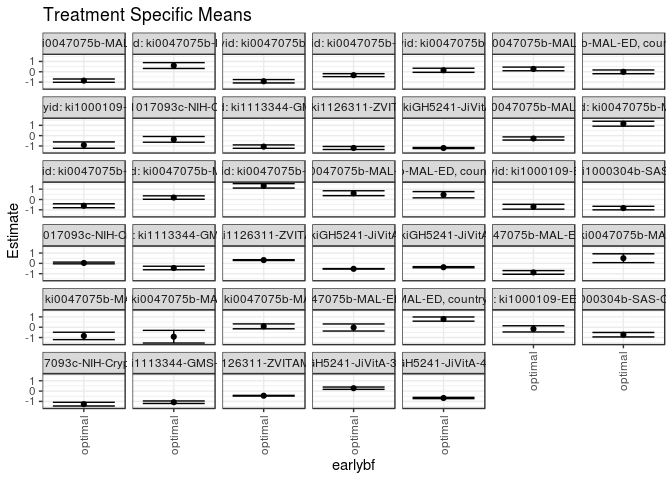

## Results Table

### Parameter: TSM

| agecat | studyid | country | intervention_level | baseline_level | estimate | ci_lower | ci_upper |
| --- | --- | --- | --- | --- | --- | --- | --- |
| Birth | ki0047075b-MAL-ED | BANGLADESH | optimal | observed | -0.8785238 | -1.0566276 | -0.7004200 |
| Birth | ki0047075b-MAL-ED | BRAZIL | optimal | observed | 0.4997399 | 0.0726993 | 0.9267805 |
| Birth | ki0047075b-MAL-ED | INDIA | optimal | observed | -0.8441424 | -1.2030400 | -0.4852448 |
| Birth | ki0047075b-MAL-ED | NEPAL | optimal | observed | -0.9176952 | -1.5308702 | -0.3045203 |
| Birth | ki0047075b-MAL-ED | PERU | optimal | observed | 0.0846536 | -0.1527593 | 0.3220665 |
| Birth | ki0047075b-MAL-ED | SOUTH AFRICA | optimal | observed | -0.0287435 | -0.3714132 | 0.3139262 |
| Birth | ki0047075b-MAL-ED | TANZANIA, UNITED REPUBLIC OF | optimal | observed | 0.7895825 | 0.5860923 | 0.9930727 |
| Birth | ki1000109-EE | PAKISTAN | optimal | observed | -0.1605922 | -0.4612622 | 0.1400778 |
| Birth | ki1000304b-SAS-CompFeed | INDIA | optimal | observed | -0.7240462 | -0.9407570 | -0.5073353 |
| Birth | ki1017093c-NIH-Crypto | BANGLADESH | optimal | observed | -1.2672605 | -1.4463571 | -1.0881639 |
| Birth | ki1113344-GMS-Nepal | NEPAL | optimal | observed | -1.0791070 | -1.1994218 | -0.9587922 |
| Birth | ki1126311-ZVITAMBO | ZIMBABWE | optimal | observed | -0.4494760 | -0.4852301 | -0.4137219 |
| Birth | kiGH5241-JiVitA-3 | BANGLADESH | optimal | observed | 0.2803179 | 0.1698414 | 0.3907944 |
| Birth | kiGH5241-JiVitA-4 | BANGLADESH | optimal | observed | -0.6708236 | -0.7320071 | -0.6096400 |
| 6 months | ki0047075b-MAL-ED | BANGLADESH | optimal | observed | -0.2763225 | -0.4294520 | -0.1231931 |
| 6 months | ki0047075b-MAL-ED | BRAZIL | optimal | observed | 1.1573300 | 0.9165912 | 1.3980688 |
| 6 months | ki0047075b-MAL-ED | INDIA | optimal | observed | -0.6062119 | -0.7964998 | -0.4159240 |
| 6 months | ki0047075b-MAL-ED | NEPAL | optimal | observed | 0.1884821 | 0.0236025 | 0.3533616 |
| 6 months | ki0047075b-MAL-ED | PERU | optimal | observed | 1.3246856 | 1.1089681 | 1.5404030 |
| 6 months | ki0047075b-MAL-ED | SOUTH AFRICA | optimal | observed | 0.6076620 | 0.3707235 | 0.8446005 |
| 6 months | ki0047075b-MAL-ED | TANZANIA, UNITED REPUBLIC OF | optimal | observed | 0.4634337 | 0.1605233 | 0.7663440 |
| 6 months | ki1000109-EE | PAKISTAN | optimal | observed | -0.7016011 | -0.9358173 | -0.4673849 |
| 6 months | ki1000304b-SAS-CompFeed | INDIA | optimal | observed | -0.8305734 | -1.0015654 | -0.6595814 |
| 6 months | ki1017093c-NIH-Crypto | BANGLADESH | optimal | observed | 0.0382604 | -0.0470547 | 0.1235755 |
| 6 months | ki1113344-GMS-Nepal | NEPAL | optimal | observed | -0.4494909 | -0.6202614 | -0.2787204 |
| 6 months | ki1126311-ZVITAMBO | ZIMBABWE | optimal | observed | 0.3180117 | 0.2790671 | 0.3569564 |
| 6 months | kiGH5241-JiVitA-3 | BANGLADESH | optimal | observed | -0.5293319 | -0.5506308 | -0.5080330 |
| 6 months | kiGH5241-JiVitA-4 | BANGLADESH | optimal | observed | -0.3736040 | -0.4260746 | -0.3211335 |
| 24 months | ki0047075b-MAL-ED | BANGLADESH | optimal | observed | -0.8583438 | -1.0178191 | -0.6988685 |
| 24 months | ki0047075b-MAL-ED | BRAZIL | optimal | observed | 0.6039549 | 0.3204875 | 0.8874222 |
| 24 months | ki0047075b-MAL-ED | INDIA | optimal | observed | -0.9186987 | -1.0813361 | -0.7560612 |
| 24 months | ki0047075b-MAL-ED | NEPAL | optimal | observed | -0.3268214 | -0.4702417 | -0.1834010 |
| 24 months | ki0047075b-MAL-ED | PERU | optimal | observed | 0.1451558 | -0.0529685 | 0.3432801 |
| 24 months | ki0047075b-MAL-ED | SOUTH AFRICA | optimal | observed | 0.2768371 | 0.0977220 | 0.4559521 |
| 24 months | ki0047075b-MAL-ED | TANZANIA, UNITED REPUBLIC OF | optimal | observed | -0.0059779 | -0.1881721 | 0.1762162 |
| 24 months | ki1000109-EE | PAKISTAN | optimal | observed | -0.9164752 | -1.2231283 | -0.6098222 |
| 24 months | ki1017093c-NIH-Crypto | BANGLADESH | optimal | observed | -0.3601968 | -0.6384868 | -0.0819067 |
| 24 months | ki1113344-GMS-Nepal | NEPAL | optimal | observed | -1.0631787 | -1.2273630 | -0.8989944 |
| 24 months | ki1126311-ZVITAMBO | ZIMBABWE | optimal | observed | -1.1956044 | -1.3421737 | -1.0490351 |
| 24 months | kiGH5241-JiVitA-4 | BANGLADESH | optimal | observed | -1.2007443 | -1.2498017 | -1.1516868 |

### Parameter: E(Y)

| agecat | studyid | country | intervention_level | baseline_level | estimate | ci_lower | ci_upper |
| --- | --- | --- | --- | --- | --- | --- | --- |
| Birth | ki0047075b-MAL-ED | BANGLADESH | observed | observed | -0.9390654 | -1.0847642 | -0.7933666 |
| Birth | ki0047075b-MAL-ED | BRAZIL | observed | observed | 0.4029032 | 0.0896793 | 0.7161272 |
| Birth | ki0047075b-MAL-ED | INDIA | observed | observed | -0.9122727 | -1.1899971 | -0.6345483 |
| Birth | ki0047075b-MAL-ED | NEPAL | observed | observed | -0.7684615 | -1.1257770 | -0.4111460 |
| Birth | ki0047075b-MAL-ED | PERU | observed | observed | -0.0520175 | -0.1725298 | 0.0684947 |
| Birth | ki0047075b-MAL-ED | SOUTH AFRICA | observed | observed | -0.1690000 | -0.3880340 | 0.0500340 |
| Birth | ki0047075b-MAL-ED | TANZANIA, UNITED REPUBLIC OF | observed | observed | 0.7624348 | 0.5710709 | 0.9537986 |
| Birth | ki1000109-EE | PAKISTAN | observed | observed | -0.3522059 | -0.5428560 | -0.1615557 |
| Birth | ki1000304b-SAS-CompFeed | INDIA | observed | observed | -0.6676026 | -0.8422097 | -0.4929956 |
| Birth | ki1017093c-NIH-Crypto | BANGLADESH | observed | observed | -1.2441513 | -1.3281130 | -1.1601897 |
| Birth | ki1113344-GMS-Nepal | NEPAL | observed | observed | -1.1260580 | -1.2184297 | -1.0336863 |
| Birth | ki1126311-ZVITAMBO | ZIMBABWE | observed | observed | -0.5262098 | -0.5537283 | -0.4986913 |
| Birth | kiGH5241-JiVitA-3 | BANGLADESH | observed | observed | -0.7778811 | -0.7969145 | -0.7588476 |
| Birth | kiGH5241-JiVitA-4 | BANGLADESH | observed | observed | -0.6886269 | -0.7410452 | -0.6362086 |
| 6 months | ki0047075b-MAL-ED | BANGLADESH | observed | observed | -0.1316250 | -0.2604010 | -0.0028490 |
| 6 months | ki0047075b-MAL-ED | BRAZIL | observed | observed | 0.9720774 | 0.8078144 | 1.1363403 |
| 6 months | ki0047075b-MAL-ED | INDIA | observed | observed | -0.7079979 | -0.8344175 | -0.5815783 |
| 6 months | ki0047075b-MAL-ED | NEPAL | observed | observed | 0.1104308 | -0.0208643 | 0.2417259 |
| 6 months | ki0047075b-MAL-ED | PERU | observed | observed | 1.0528816 | 0.9313005 | 1.1744626 |
| 6 months | ki0047075b-MAL-ED | SOUTH AFRICA | observed | observed | 0.5500267 | 0.3964966 | 0.7035568 |
| 6 months | ki0047075b-MAL-ED | TANZANIA, UNITED REPUBLIC OF | observed | observed | 0.5362213 | 0.4049390 | 0.6675036 |
| 6 months | ki1000109-EE | PAKISTAN | observed | observed | -0.7725778 | -0.8877440 | -0.6574117 |
| 6 months | ki1000304b-SAS-CompFeed | INDIA | observed | observed | -0.6657084 | -0.8024377 | -0.5289791 |
| 6 months | ki1017093c-NIH-Crypto | BANGLADESH | observed | observed | 0.0297622 | -0.0491685 | 0.1086930 |
| 6 months | ki1113344-GMS-Nepal | NEPAL | observed | observed | -0.5843738 | -0.6761994 | -0.4925481 |
| 6 months | ki1126311-ZVITAMBO | ZIMBABWE | observed | observed | 0.3072633 | 0.2799882 | 0.3345385 |
| 6 months | kiGH5241-JiVitA-3 | BANGLADESH | observed | observed | -0.5935161 | -0.6130518 | -0.5739805 |
| 6 months | kiGH5241-JiVitA-4 | BANGLADESH | observed | observed | -0.3898055 | -0.4270507 | -0.3525603 |
| 24 months | ki0047075b-MAL-ED | BANGLADESH | observed | observed | -0.8141706 | -0.9363085 | -0.6920327 |
| 24 months | ki0047075b-MAL-ED | BRAZIL | observed | observed | 0.4626233 | 0.2567495 | 0.6684971 |
| 24 months | ki0047075b-MAL-ED | INDIA | observed | observed | -0.9516520 | -1.0670654 | -0.8362385 |
| 24 months | ki0047075b-MAL-ED | NEPAL | observed | observed | -0.3749123 | -0.4886073 | -0.2612173 |
| 24 months | ki0047075b-MAL-ED | PERU | observed | observed | 0.1111982 | -0.0118399 | 0.2342362 |
| 24 months | ki0047075b-MAL-ED | SOUTH AFRICA | observed | observed | 0.4152943 | 0.2928804 | 0.5377083 |
| 24 months | ki0047075b-MAL-ED | TANZANIA, UNITED REPUBLIC OF | observed | observed | 0.0547975 | -0.0703378 | 0.1799328 |
| 24 months | ki1000109-EE | PAKISTAN | observed | observed | -1.0044512 | -1.1543739 | -0.8545285 |
| 24 months | ki1017093c-NIH-Crypto | BANGLADESH | observed | observed | -0.6103502 | -0.7050157 | -0.5156847 |
| 24 months | ki1113344-GMS-Nepal | NEPAL | observed | observed | -1.1339602 | -1.2266932 | -1.0412272 |
| 24 months | ki1126311-ZVITAMBO | ZIMBABWE | observed | observed | -1.1970712 | -1.3045749 | -1.0895676 |
| 24 months | kiGH5241-JiVitA-4 | BANGLADESH | observed | observed | -1.2231088 | -1.2549632 | -1.1912543 |

### Parameter: PAR

| agecat | studyid | country | intervention_level | baseline_level | estimate | ci_lower | ci_upper |
| --- | --- | --- | --- | --- | --- | --- | --- |
| Birth | ki0047075b-MAL-ED | BANGLADESH | optimal | observed | -0.0605416 | -0.1682532 | 0.0471700 |
| Birth | ki0047075b-MAL-ED | BRAZIL | optimal | observed | -0.0968367 | -0.3770566 | 0.1833833 |
| Birth | ki0047075b-MAL-ED | INDIA | optimal | observed | -0.0681303 | -0.2379868 | 0.1017261 |
| Birth | ki0047075b-MAL-ED | NEPAL | optimal | observed | 0.1492337 | -0.2735437 | 0.5720111 |
| Birth | ki0047075b-MAL-ED | PERU | optimal | observed | -0.1366711 | -0.3449346 | 0.0715923 |
| Birth | ki0047075b-MAL-ED | SOUTH AFRICA | optimal | observed | -0.1402565 | -0.3609323 | 0.0804193 |
| Birth | ki0047075b-MAL-ED | TANZANIA, UNITED REPUBLIC OF | optimal | observed | -0.0271477 | -0.0893246 | 0.0350292 |
| Birth | ki1000109-EE | PAKISTAN | optimal | observed | -0.1916137 | -0.4390459 | 0.0558185 |
| Birth | ki1000304b-SAS-CompFeed | INDIA | optimal | observed | 0.0564435 | -0.1415590 | 0.2544461 |
| Birth | ki1017093c-NIH-Crypto | BANGLADESH | optimal | observed | 0.0231092 | -0.1304694 | 0.1766878 |
| Birth | ki1113344-GMS-Nepal | NEPAL | optimal | observed | -0.0469510 | -0.1273525 | 0.0334505 |
| Birth | ki1126311-ZVITAMBO | ZIMBABWE | optimal | observed | -0.0767338 | -0.1006204 | -0.0528473 |
| Birth | kiGH5241-JiVitA-3 | BANGLADESH | optimal | observed | -1.0581990 | -1.1703649 | -0.9460331 |
| Birth | kiGH5241-JiVitA-4 | BANGLADESH | optimal | observed | -0.0178033 | -0.0633933 | 0.0277868 |
| 6 months | ki0047075b-MAL-ED | BANGLADESH | optimal | observed | 0.1446975 | 0.0267816 | 0.2626134 |
| 6 months | ki0047075b-MAL-ED | BRAZIL | optimal | observed | -0.1852527 | -0.3542823 | -0.0162230 |
| 6 months | ki0047075b-MAL-ED | INDIA | optimal | observed | -0.1017859 | -0.2529793 | 0.0494074 |
| 6 months | ki0047075b-MAL-ED | NEPAL | optimal | observed | -0.0780513 | -0.1862527 | 0.0301501 |
| 6 months | ki0047075b-MAL-ED | PERU | optimal | observed | -0.2718040 | -0.4474446 | -0.0961634 |
| 6 months | ki0047075b-MAL-ED | SOUTH AFRICA | optimal | observed | -0.0576353 | -0.2268301 | 0.1115594 |
| 6 months | ki0047075b-MAL-ED | TANZANIA, UNITED REPUBLIC OF | optimal | observed | 0.0727877 | -0.2019131 | 0.3474884 |
| 6 months | ki1000109-EE | PAKISTAN | optimal | observed | -0.0709768 | -0.2782112 | 0.1362577 |
| 6 months | ki1000304b-SAS-CompFeed | INDIA | optimal | observed | 0.1648650 | -0.0522322 | 0.3819621 |
| 6 months | ki1017093c-NIH-Crypto | BANGLADESH | optimal | observed | -0.0084982 | -0.0381968 | 0.0212005 |
| 6 months | ki1113344-GMS-Nepal | NEPAL | optimal | observed | -0.1348829 | -0.2760310 | 0.0062652 |
| 6 months | ki1126311-ZVITAMBO | ZIMBABWE | optimal | observed | -0.0107484 | -0.0378583 | 0.0163616 |
| 6 months | kiGH5241-JiVitA-3 | BANGLADESH | optimal | observed | -0.0641843 | -0.0778847 | -0.0504839 |
| 6 months | kiGH5241-JiVitA-4 | BANGLADESH | optimal | observed | -0.0162015 | -0.0537681 | 0.0213652 |
| 24 months | ki0047075b-MAL-ED | BANGLADESH | optimal | observed | 0.0441732 | -0.0577616 | 0.1461079 |
| 24 months | ki0047075b-MAL-ED | BRAZIL | optimal | observed | -0.1413316 | -0.3438024 | 0.0611392 |
| 24 months | ki0047075b-MAL-ED | INDIA | optimal | observed | -0.0329533 | -0.1644265 | 0.0985199 |
| 24 months | ki0047075b-MAL-ED | NEPAL | optimal | observed | -0.0480909 | -0.1501900 | 0.0540082 |
| 24 months | ki0047075b-MAL-ED | PERU | optimal | observed | -0.0339576 | -0.2029121 | 0.1349968 |
| 24 months | ki0047075b-MAL-ED | SOUTH AFRICA | optimal | observed | 0.1384573 | 0.0011049 | 0.2758096 |
| 24 months | ki0047075b-MAL-ED | TANZANIA, UNITED REPUBLIC OF | optimal | observed | 0.0607754 | -0.0692230 | 0.1907738 |
| 24 months | ki1000109-EE | PAKISTAN | optimal | observed | -0.0879760 | -0.3773604 | 0.2014084 |
| 24 months | ki1017093c-NIH-Crypto | BANGLADESH | optimal | observed | -0.2501534 | -0.5072701 | 0.0069632 |
| 24 months | ki1113344-GMS-Nepal | NEPAL | optimal | observed | -0.0707815 | -0.2109772 | 0.0694141 |
| 24 months | ki1126311-ZVITAMBO | ZIMBABWE | optimal | observed | -0.0014669 | -0.1094955 | 0.1065618 |
| 24 months | kiGH5241-JiVitA-4 | BANGLADESH | optimal | observed | -0.0223645 | -0.0594684 | 0.0147394 |